# Main Experiment Analysis

## Main analysis

Participants make one rating of responsibility for each of the three players (including themself) on each trial. These data are averaged in order to conduct ANOVA by organising each rating on each trial according to the following factors:

- ANOVA:
  - *Outcome valence*: Whether the trial result is *Reward* or *No reward*
  - *Outcome recipient*: Whether the rated player is the *Outcome owner* or *Not outcome owner*
  - *Is participant*: Whether the rated player is the *Participant* or *Another player*

The main analysis is a 2x2x2 frequentist ANOVA.

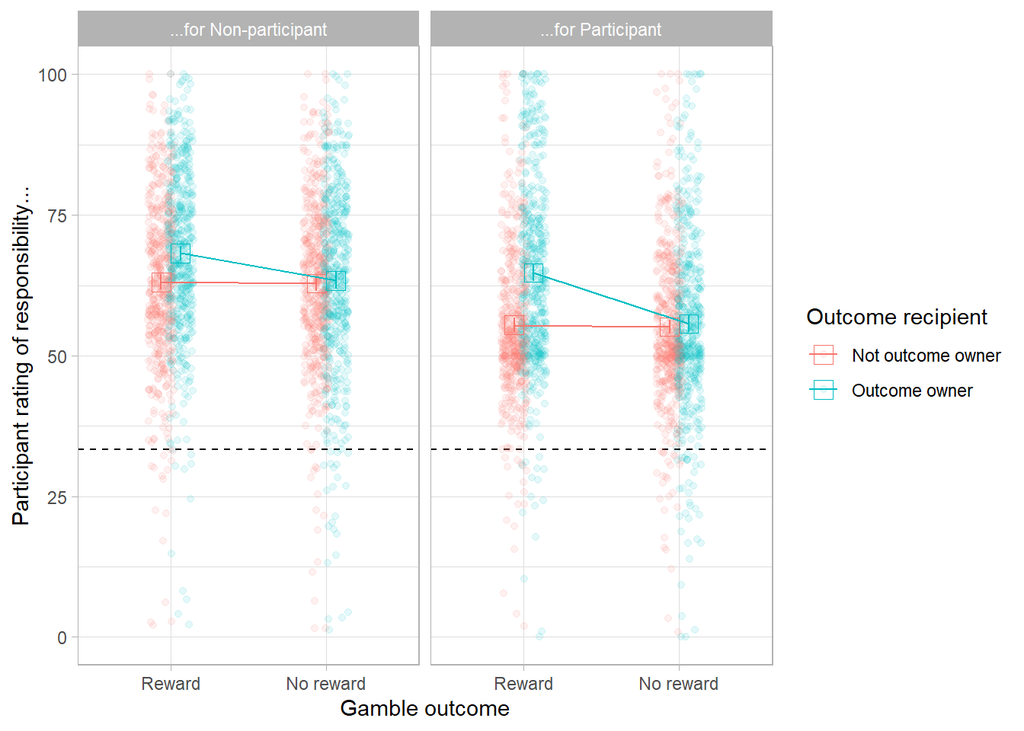

```
## $ANOVA
##                                      Effect DFn DFd         F            p
## 2                                   outcome   1 499 139.42457 1.517929e-28
## 3                        rated_gets_outcome   1 499 119.34764 4.675788e-25
## 4                            is_participant   1 499  84.48460 1.044893e-18
## 5                outcome:rated_gets_outcome   1 499 109.53455 2.618752e-23
## 6                    outcome:is_participant   1 499  30.42063 5.591751e-08
## 7         rated_gets_outcome:is_participant   1 499  47.47079 1.689256e-11
## 8 outcome:rated_gets_outcome:is_participant   1 499  56.47972 2.648993e-13
##   p<.05         ges
## 2     * 0.013463927
## 3     * 0.015324493
## 4     * 0.043653451
## 5     * 0.011427647
## 6     * 0.001197208
## 7     * 0.001152027
## 8     * 0.001092928
```

## Further inferential statistics

Below, we unfold the ANOVA results by responding to each of our research questions with a plot. For interactions, we conduct additional post-hoc t-tests to better understand the interaction effects.

### 1) Are players considered more responsible if they are the *Outcome owner*?

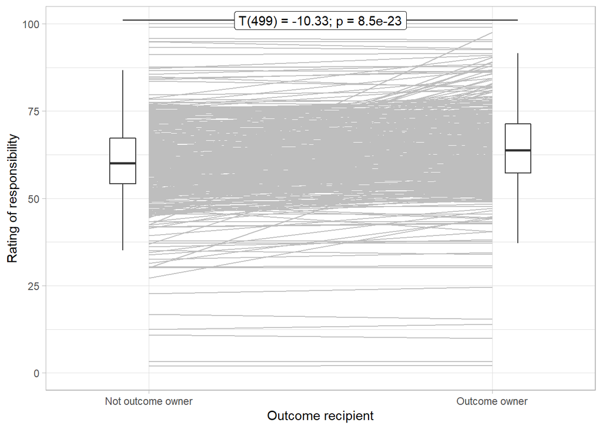

The figure shows participant mean responsibility ratings collapsed across other trial factors (lines) and their distributions (box plots). Participants rate players’ responsibility as higher when that player receives the outcome.

### 2) Does the self/other-serving bias, i.e, higher responsibility for positive *Outcome valence*, change if the rated player is *Not outcome owner*?

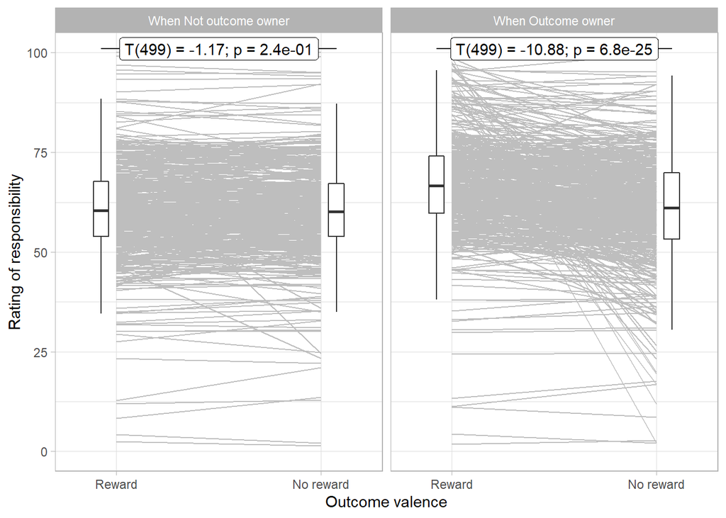

The figure shows participant mean responsibility ratings collapsed across other trial factors (lines) and their distributions (box plots). The ‘self/other-serving bias’ is evident on trials where the rated player gets the outcome, but not where another player gets the outcome.

# Interpretation

# References

# Credits

## R Packages

[output not shown]

## Funding

Marwa El Zein is a Sir Henry Wellcome Postdoctoral Fellow at University College London, funded by The Wellcome Trust (grant number 204702).

Matt Jaquiery is funded by a studentship from the [Medical Research Council](https://mrc.ukri.org/) (reference 1943590) and the University of Oxford [Department of Experimental Psychology](https://www.psy.ox.ac.uk/) (reference 17/18_MSD_661552).

## Technical details